# Comments for MEDB 5501, Week 10, part 1

## The two by two table

```
               Outcome
              Yes   No
Exposure Yes  O_11 O_12
          No  O_21 O_22
```

## Example of a two by two table

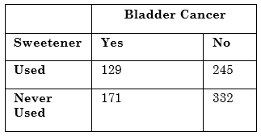

Source: [CDC](https://www.cdc.gov/epiinfo/user-guide/statcalc/tablestwobytwo.html)

## Inputting this table into SPSS

```
"sweetener","bladder_cancer","count"
1,1,129
1,2,245
2,1,171
2,2,332
```

## Use weights, 1 of 4

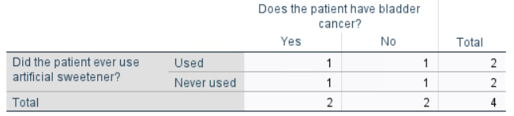

## Use weights, 2 of 4

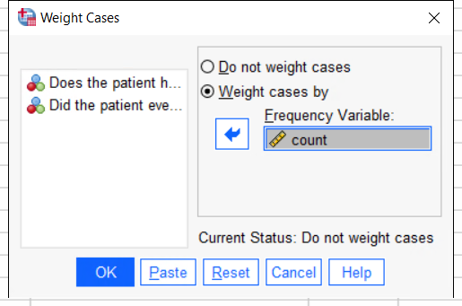

## Use weights, 3 of 4

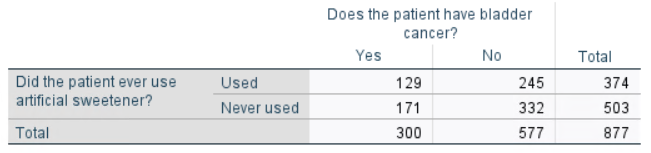

## Use weights, 4 of 4

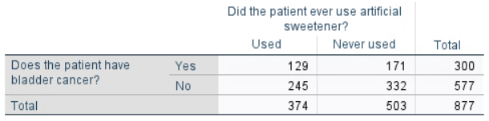

## Remember how you coded your categories, 1 of 2

New coding

```
"sweetener","bladder_cancer","count"
2,1,129
2,2,245
1,1,171
1,2,332
```

Original coding

```
"sweetener","bladder_cancer","count"
1,1,129
1,2,245
2,1,171
2,2,332
```

## Remember how you coded your categories, 2 of 2

New coding

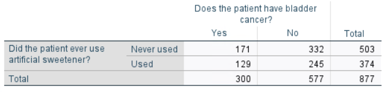

Original coding

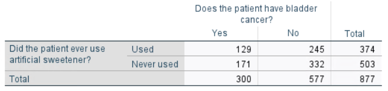

## Pfizer vaccine example, 1 of 4

[figure not shown]

## Pfizer vaccine example, 2 of 4

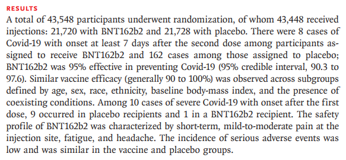

## Pfizer vaccine example, 3 of 4

```
Numbers from the abstract

         Covid  No covid   Total
Vaccine     8       ?     21,720
Placebo   162       ?     21,728
Total       ?       ?     43,448

Numbers inferred

         Covid  No covid   Total
Vaccine     8    21,712   21,720
Placebo   162    21,566   21,728
Total     170    43,278   43,448
```

## Pfizer vaccine example, 4 of 4

```
shot,outcome,count
1,1,8
1,0,21712
0,1,162
0,0,21566
```

## How to measure risk

*Dear Professor Mean: There is some confusion about the use of the odds ratio versus the relative risk. Can you explain the difference between these two numbers?*

## Titanic data

```
          Alive   Dead  Total
  Female    308    154    462
  Male      142    709    851
  Total     450    863  1,313
```

## Odds ratio calculation

```
          Alive   Dead  Total  Odds
  Female    308    154    462  154/308 = 0.5
  Male      142    709    851  709/142 = 4.993
  Total     450    863  1,313

OR = 4.993 / 0.5 = 9.986
```

## Relative risk calculation

```
          Alive   Dead  Total  Probability
  Female    308    154    462  154/462 = 0.3333
  Male      142    709    851  709/851 = 0.8331
  Total     450    863  1,313

RR = 0.8331 / 0.3333 = 2.499
```

## Relative risk versus odds ratio

- Relative risks
  - Consistent with our perceptions of risk
  - Cannot be computed for some research designs
  - Sometimes ambiguous

## Fractions are funny

- Stock investment of $1,000
  - First day decease by 20%
  - Second day increase by 20%
- Investment after one day
  - $\$1,000 \times 0.8=\$800$
- Investment after two days
  - $\$800 \times 1.2=\$960$
- An increase of 25% (1.25 = 5/4) is needed to counteract a decrease of 20% (0.8 = 4/5).

## [Car Talk puzzler](https://www.cartalk.com/radio/puzzler/porch-potatoes-0)

RAY: Potatoes are 99 percent water and one percent what? Potato. So say you take a bunch of potatoes, like 100 pounds of potatoes and you set them out on your back porch to dry out.

TOM: Yeah, when they are dry they should weigh about a pound.

RAY: Well, not drying out completely. And as they dry out the water begins to evaporate. And after a while, enough water has evaporated so that the potatoes are now 98 percent water. If you were to weigh those potatoes at that moment…

TOM: They’d be lighter.

RAY: Yes, how much lighter?

## Reciprocal fractions

```
  Fraction    Reciprocal
  0.8  (4/5)  1.25 (5/4)
  0.75 (3/4)  1.33 (4/3)
  0.67 (2/3)  1.50 (3/2)
  0.50 (1/2)  2.00 (2/1)
```

## Interpretability of the relative risk, 1 of 3

```
         Alive   Dead  Total
Exposed    200    200   400
Control    300    100   400

RR = 0.5 / 0.25 = 2
OR   3.0 / 1.0  = 3
```

## Interpretability of the relative risk, 2 of 3

```
         Alive   Dead  Total
Exposed    200    200   400
Control    360     40   400

RR = 0.5 / 0.1   = 5
OR   9.0 / 1.0   = 9
```

## Interpretability of the relative risk, 3 of 3

```
         Alive   Dead  Total
Exposed     40    360   400
Control    360     40   400

RR = 0.9 / 0.1   =  9
OR   9.0 / 0.111 = 81
```

## Risk in a case/control study

[output not shown]

## Risk in a cohort study

```
         Heart disease       Healthy     Total
Balding    127 (9.4%)     1,224 (90.6%)  1,351
  Hairy    548 (6.7%)     7,611 (93.3%)  8,159
  Total    675            8,835          9,510

Relative risk or odds ratio is interpretable.
```

## Risk adjustment

```
          Children   No children  Total
Epilepsy  232 (40%)  354 (60%)      586
 Control   79 (72%)   30 (28%)      109
   Total  311        384            695

OR = 0.25 (unadjusted)
   = 0.36 (adjusted for age and other covariates)
```

## Ambiguous and confusing situations, 1 of 2

```
                 No cath       Cath      Total
  Male patient  34 ( 9.4%)  326 (90.6%)   360
Female patient  55 (15.3%)  305 (84.7%)   360
         Total  89          631           720

OR = (326/34) / (305/55) = 9.588 / 5.545 = 1.73 (reciprocal 0.58)
RR(Cath)    = 0.906 / 0.847 = 1.07 (reciprocal 0.93)
RR(No cath) = 0.094 / 0.153 = 0.61 (reciprocal 1.63)
```

## Ambiguous and confusing situations, 2 of 2

```
           Continued bf  Stopped bf  Total
Treatment   19 (37.3%)   32 (62.7%)    51
  Control    5 ( 8.8%)   52 (91.2%)    57
    Total   24           84           108

OR = (32/19) / (52/5) = 1.684 / 10.400 = 0.16 (reciprocal 6.2)
RR (Stopped bf)   = 0.627 / 0.912 = 0.69 (reciprocal 1.45)
RR (Continued bf) = 0.373 / 0.088 = 4.3  (reciprocal 0.23)
```

While the **relative risk of 0.69 (reciprocal 1.45)** for this data is much less extreme than the **odds ratio of 0.16 (reciprocal 6.2)**, one has to wonder why Deeks chose to compare probabilities of breast feeding failures rather than successes. The **rate of successful breast feeding at three months was 4.2 times higher in the treatment group than the control group**. This is still not as extreme as the odds ratio; the **odds ratio for successful breast feeding is 6.25**, which is simply the inverse of the odds ratio for breast feeding failure.

**One advantage of the odds ratio is that it is not dependent on whether we focus on the event’s occurrence or its failure to occur**. If the odds ratio for an event deviates substantially from 1.0, the odds ratio for the event’s failure to occur will also deviate substantially from 1.0, though in the opposite direction.

## Summary

- Relative risks
  - Consistent with our perceptions of risk
  - Cannot be computed for some research designs
  - Sometimes ambiguous

## Absolute risk reduction

[output not shown]

## Advantages of absolute risk reduction

If the control probability is small, even a large relative change can be trivial.

- Untreated sleep apnea triples the risk of stroke.
- Smoking
  - Ten fold increase in risk of lung cancer
  - Doubling in the risk of heart attack